# Low Birth Weight data set - Logistic Regression and Visualization

The goal of this Ipython notebook initially was to explore Logistic Regression, but it has become more about visually exploring the low birth weight dataset and implementing Logistic Regression by using L1 and L2 penalties. I also looked a bit at PCA and feature selection, while plotting a mix of different aspects such as coefficients and distributions of the data.

```python
%matplotlib inline
import numpy as np
import pandas as pd
import matplotlib.pyplot as pyplot
from matplotlib import cm
import seaborn as sns
from pandas.tools.plotting import andrews_curves
from mpl_toolkits.mplot3d import Axes3D
from sklearn import linear_model
from sklearn.linear_model import LogisticRegression
from sklearn.metrics import accuracy_score
from sklearn.cross_validation import train_test_split
# ignoring Pandas warnings:
# http://stackoverflow.com/questions/19554900/scikitlearn-breaks-pandas-installation
import warnings
warnings.filterwarnings("ignore", category=DeprecationWarning,
                        module="pandas", lineno=570)
warnings.filterwarnings("ignore", category=DeprecationWarning,
                        module="statsmodels", lineno=19)
```

```python
# read low birth weight dataset
lbw = pd.read_table('/Users/Gabi/DataScience/lowbwt.txt', header= None,
                    names= ['id','low','age','lwt','race','smoke','ptl','ht','ui','ftv','bwt'] )
```

A quick look at what the data looks like:

```python
lbw.head()
```

|  | id | low | age | lwt | race | smoke | ptl | ht | ui | ftv | bwt |
| --- | --- | --- | --- | --- | --- | --- | --- | --- | --- | --- | --- |
| 0 | 85 | 0 | 19 | 182 | 2 | 0 | 0 | 0 | 1 | 0 | 2523 |
| 1 | 86 | 0 | 33 | 155 | 3 | 0 | 0 | 0 | 0 | 3 | 2551 |
| 2 | 87 | 0 | 20 | 105 | 1 | 1 | 0 | 0 | 0 | 1 | 2557 |
| 3 | 88 | 0 | 21 | 108 | 1 | 1 | 0 | 0 | 1 | 2 | 2594 |
| 4 | 89 | 0 | 18 | 107 | 1 | 1 | 0 | 0 | 1 | 0 | 2600 |

```python
label = lbw[['low']]; #label to predict
features = lbw.loc[:, 'age':'bwt']; #ignore id
```

We split the data for training and testing using train-test-split from sklearn: 66% is allocated to training and 34% for testing

```python
# split data for training and testing: training = 66% and testing = 34%
train, test, label_train, label_test =  train_test_split(features, label , test_size = .34, random_state =42)
```

```python
# turn train into dataframe (train_test_split returns array with no column names)
train = pd.DataFrame(train, columns = ['age','lwt','race','smoke','ptl','ht','ui','ftv','bwt'] )
# set x
x = train
# set label - need to ravel in order to flatten to 1d array
y = np.ravel(label_train)
print("x:\n",x.head())
```

```
x:
    age  lwt  race  smoke  ptl  ht  ui  ftv   bwt
0   29  135     1      0    0   0   0    1  3651
1   30  110     3      0    0   0   0    0  3475
2   26  154     3      0    1   1   0    1  2442
3   19  138     1      1    0   0   0    2  2977
4   16  170     2      0    0   0   0    4  3860
```

```python
# create training set with training data and label
training = train.copy()
training['low']=label_train
training.head()
```

|  | age | lwt | race | smoke | ptl | ht | ui | ftv | bwt | low |
| --- | --- | --- | --- | --- | --- | --- | --- | --- | --- | --- |
| 0 | 29 | 135 | 1 | 0 | 0 | 0 | 0 | 1 | 3651 | 0 |
| 1 | 30 | 110 | 3 | 0 | 0 | 0 | 0 | 0 | 3475 | 0 |
| 2 | 26 | 154 | 3 | 0 | 1 | 1 | 0 | 1 | 2442 | 1 |
| 3 | 19 | 138 | 1 | 1 | 0 | 0 | 0 | 2 | 2977 | 0 |
| 4 | 16 | 170 | 2 | 0 | 0 | 0 | 0 | 4 | 3860 | 0 |

```python
# turn test into dataframe (train_test_split returns array with no column names)
test = pd.DataFrame(test, columns = ['age','lwt','race','smoke','ptl','ht','ui','ftv','bwt'] )
# set x
x_test = test
# set label - need to ravel in order to flatten to 1d array
y_test = np.ravel(label_test)
print("x_test:\n",x_test.head())
```

```
x_test:
    age  lwt  race  smoke  ptl  ht  ui  ftv   bwt
0   28   95     1      1    0   0   0    2  2466
1   18  148     3      0    0   0   0    0  2282
2   20  120     3      0    0   0   1    0  2807
3   18  100     1      1    0   0   0    0  2769
4   28  250     3      1    0   0   0    6  3303
```

### Visually Exploring the data

In order to explore the data, I used scatter-matrix from pandas to show the pairwise correlations between different variables.

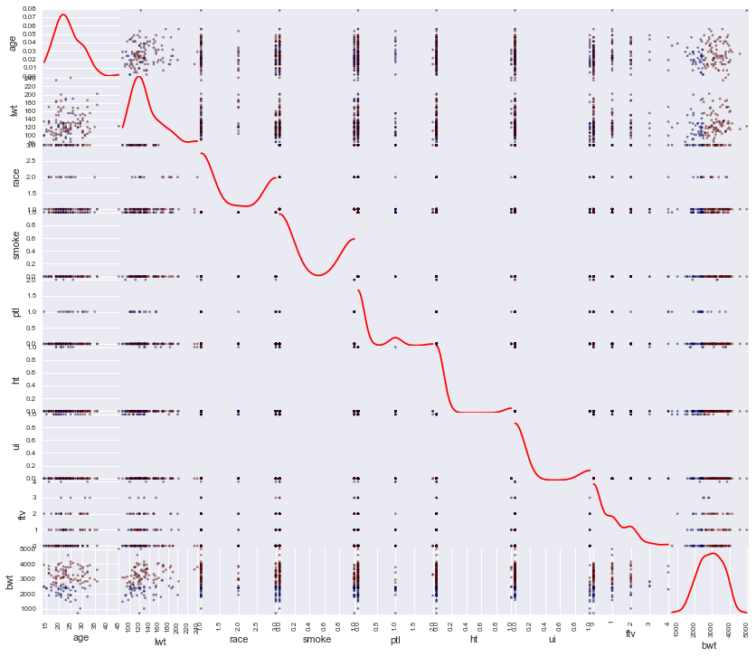

```python
# exploring data correlations by using scatter matrix -- too many features
from pandas.tools.plotting import scatter_matrix
axeslist=scatter_matrix(x, alpha=0.5, figsize=(14, 12), diagonal="kde", density_kwds={'color':'red'},
                        c = training.low, cmap = cm.jet_r)
for ax in axeslist.flatten():
    ax.grid(True)
```

Using the training set as input with all the features doesn't add much value, so I reduced the input to another version of the training set with only age, lwt (weight in lbs of mother at last menstrual period), and bwt.

LWT and AGE: the points seem to be mixed: many women between 15 and 35 are in the 100-200 lbs range with mixed outcomes of baby birth weights, and there seem to be a few outliers where weight is over 200 lbs.

LWT and BWT (birth weight in grams - where bwt $<2500g$ is considered low): Since the data set contains fewer low birth weight samples it seems like there are more normal babies born to mothers where the weight in lbs at last menstrual period ranges from high to low. If we look at birth weight $<2500g$ in blue, it looks like there are more women below 130 lbs.

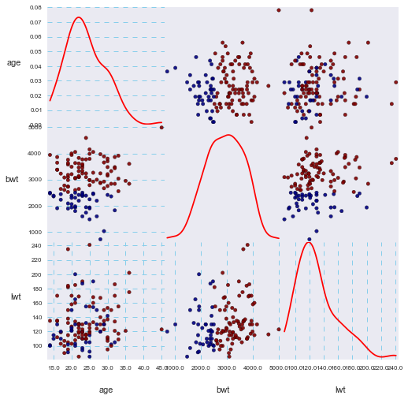

```python
# reduced x input to fewer features
x2 = x[['age','bwt','lwt']]
axeslist=pd.scatter_matrix(x2, alpha=0.9, figsize=(8,8), diagonal="kde", density_kwds={'color':'red'},
                        c = training.low, marker ='o', cmap = cm.jet_r)
for ax in axeslist.flatten():
    ax.grid(True, axis = 'both', which='both',  linestyle='--', linewidth=1, c='skyblue')
    x_ticks = ax.get_xticks()
    x_labels = ax.get_xlabel()
    ax.set_xticklabels(x_ticks, rotation=0)
    ax.set_xlabel(x_labels, rotation = 0, labelpad = 20)
    y_labels = ax.get_ylabel()
    ax.set_ylabel(y_labels, rotation = 0, labelpad=20)
```

```python
# create 2 dataframes to check that colored correctly
red = training.loc[training.low ==0]
blue = training.loc[training.low ==1]
```

```python
# some checks
red.loc[red.age>35.0]
red.age.max()
training.age.max()
```

```
45
```

### Further exploring features in the data

Next, I created a few smaller dataframes to further explore the different features in the training data.

#### Mother's weight at last period and birth weight of baby

The first scatter plot shows mother's weight at last period and birth weight of baby: The red points represent normal weight babies and the blue points correspond to low birth weight babies ($<2500g$). There seems to be a cluster of low birth weight babies where the weight of the mother is below $125 lbs$ but there is no clear trend.

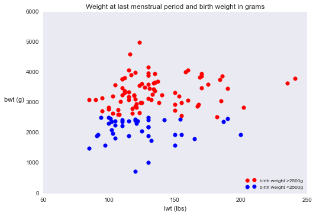

```python
# dataframe for lwt & bwt (weight at last period & birth weight of baby)
x_lwtbwt = x.loc[:, ['lwt','bwt']]
# Scatter plot of weight at last period and birth weight of baby (training set)
fig = pyplot.figure()
ax = fig.add_subplot(1,1,1)
ax.scatter(x_lwtbwt.ix[y==0, 0], x_lwtbwt.ix[y==0, 1], c= 'r', edgecolors = 'r', label = 'birth weight >2500g', s= 45) # lwt
ax.scatter(x_lwtbwt.ix[y==1, 0], x_lwtbwt.ix[y==1, 1], c= 'b', edgecolors = 'b', label = 'birth weight <2500g', s= 45) # bwt
pyplot.xlabel(x_lwtbwt.columns[0] + " (lbs)")
pyplot.ylabel(x_lwtbwt.columns[1] + " (g)" , rotation = 0, labelpad=20 )
ax.grid(which='major')
ax.legend(loc = 4, fontsize='small', scatterpoints=2, fancybox = True)
ax.set_title('Weight at last menstrual period and birth weight in grams', fontsize = 'large')
pyplot.show(fig)
```

#### Race Birth weight race

This next subset of the training data shows race and baby birth weight. Here we can see that there are fewer samples of black women and more white women. Also, women labeled as 'other' race seem to have about half low birth weight babies and half normal weight.

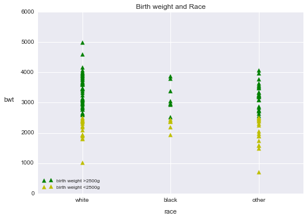

```python
# dataframe for race & bwt
x_racebwt = x.loc[:, ['race','bwt']]

# change tick labels for race
x_TicksNew = [item for item in ['white','black','other']]

# plot points from training set of bwt and race
fig1 = pyplot.figure()
ax = fig1.add_subplot(1,1,1)
ax.scatter(x_racebwt.ix[y==0, 0], x_racebwt.ix[y==0, 1], c= 'g', edgecolors = 'g', label = 'birth weight >2500g', s= 45, marker ='^') # race
ax.scatter(x_racebwt.ix[y==1, 0], x_racebwt.ix[y==1, 1], c= 'y', edgecolors = 'y', label = 'birth weight <2500g', s= 45, marker ='^') # bwt
pyplot.xlabel(x_racebwt.columns[0], labelpad = 10) #labelpad: add space btw points and label
pyplot.ylabel(x_racebwt.columns[1], rotation = 0, labelpad = 20)
ax.grid(which='major')
x_plot_labels = [item.get_text() for item in ax.get_xticklabels()]
x_plot_labels[1] = 'White'
x_plot_labels[2]='Black'
x_plot_labels[3]='Other'
ax.set_xticklabels(x_TicksNew)
ax.set_xticks([1,2,3])
ax.legend(loc = 3, fontsize='small', scatterpoints=2, fancybox = True)
ax.set_title('Birth weight and Race', fontsize = 'large')
ax.grid(True)
pyplot.show(fig1)
```

#### Race, age and birth weight

While noticing that there are fewer samples of black women and more white women, I wanted to drill in and see the actual percentages in the data and represent this in a bar graph. In doing so, I noted that less than $15\%$ of the data contained black women.

```python
# create a second version of dataframe where we replace race numbers 1,2 3 with types and add age column
x_racebwt_2 =  x.loc[:, ['race','age','bwt']].replace([1,2,3],['white','black','other'])
#x_racebwt.replace([1,2,3],['white','black','other'])
x_racebwt_2.head()
```

|  | race | age | bwt |
| --- | --- | --- | --- |
| 0 | white | 29 | 3651 |
| 1 | other | 30 | 3475 |
| 2 | other | 26 | 2442 |
| 3 | white | 19 | 2977 |
| 4 | black | 16 | 3860 |

```python
# check that correct replacements were made
print("Check replacements made, first 4 should be false\n", x_racebwt_2.race.isin(["black"]).head(),
      "\n\n",x_racebwt_2.loc[x_racebwt_2.race=="white"].head())
```

```
Check replacements made, first 4 should be false
 0    False
1    False
2    False
3    False
4     True
Name: race, dtype: bool

     race  age   bwt
0  white   29  3651
3  white   19  2977
5  white   36  2836
6  white   20  3940
7  white   24  4593
```

```python
# fewest black samples:
total_count = x_racebwt_2.race.value_counts().sum()
count_races = pd.DataFrame(x_racebwt_2.race.value_counts(),
                           columns=['race_count'])
print("Total count:", total_count, "\n")
print(count_races.head())
```

```
Total count: 124

       race_count
white          67
other          43
black          14
```

```
       race_count  percents
white          67  0.540323
other          43  0.346774
black          14  0.112903
```

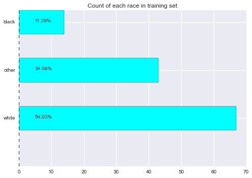

```python
# take a look at percents of each race in training set
count_races['percents']= count_races/total_count
print(count_races.head())
ax = count_races.race_count.plot(kind = 'barh', cmap = cm.cool);
ax.set_title("Count of each race in training set")
# annotate plot with percentages
for i, var in enumerate(count_races.percents):
    ax.annotate(np.str(np.round(count_races.percents[i],4)*100)+"%", (5,i))
```

When plotting each race separately, the minimum birth weight is the lowest for 'other' race women seemingly close to $700g$ while the maximum is close to $5000g$ for white women. Also, the range of birth weight for black women is between $1928g$ and $3860g$.

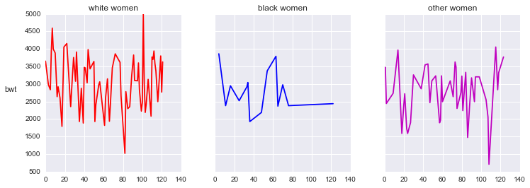

```python
# plot lines of the diff birth weights by race
cols = ['red','blue','magenta']
x_racebwt_v2 = x_racebwt.replace([1,2,3],['white','black','other'])
fig, axes = pyplot.subplots(nrows=1, ncols=3, figsize=(12,4), sharey=True)
for i, var in enumerate(['white','black','other']):
    x_racebwt_v2.loc[x_racebwt_v2.race==var].plot(ax = axes[i], title = var + " women" , color=cols[i], legend = '')
axes[0].set_ylabel('bwt', rotation = 0, labelpad = 20)
fig.subplots_adjust(hspace=0.25, wspace=0.25)
pyplot.show(fig)
```

```python
# find min and max for black women
print("min", min(x_racebwt_v2.bwt.loc[x_racebwt_v2.race=="black"]))
print("max", max(x_racebwt_v2.bwt.loc[x_racebwt_v2.race=="black"]))
```

```
min 1928
max 3860
```

#### Smoke and birth weight

In the next visualization, it looks like the training set has less women who smoke and also more women who smoke and have low weight babies.

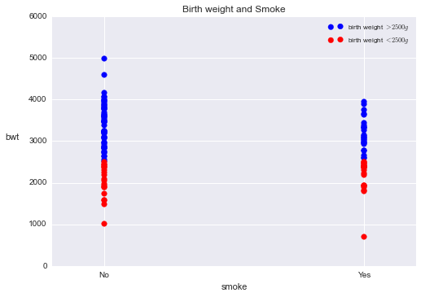

```python
# dataframe for smoke & bwt
x_smokebwt = x.loc[:, ['smoke','bwt']]
# plot points from training set of smoke & bwt
fig2 = pyplot.figure()
ax = fig2.add_subplot(1,1,1)
ax.scatter(x_smokebwt.ix[y==0, 0], x_smokebwt.ix[y==0, 1], c= 'blue', edgecolors = 'blue', label = 'birth weight $>2500g$', s= 45) # smoke
ax.scatter(x_smokebwt.ix[y==1, 0], x_smokebwt.ix[y==1, 1], c= 'red', edgecolors = 'red', label ='birth weight $<2500g$', s= 45) # bwt
#pyplot.xlim(x_agesmoke[['age']].min() - 2  , x_agesmoke[['age']].max() + 2 ) # set limits of x axis (age)
#pyplot.ylim(x_agesmoke[['smoke']].min() - 2, x_agesmoke[['smoke']].max() + 2 ) # set limits of y axis (race)
pyplot.xlabel(x_smokebwt.columns[0])
pyplot.ylabel(x_smokebwt.columns[1], rotation=0, labelpad=20) #rotate label and add space
ax.legend(loc = "best", fontsize='small', scatterpoints=2, fancybox = True)
ax.set_title('Birth weight and Smoke', fontsize = 'large')


# change tick labels for smoke
x_TickNew = [item for item in ['No','Yes']]
# get tick labels
xplot_labels = [item.get_text() for item in ax.get_xticklabels()]
# change to only 2 labels - No and Yes
xplot_labels[0]='No'
xplot_labels[1]='Yes'
ax.set_xticklabels(x_TickNew)
# need to also change the ticks for x-axis
ax.set_xticks([0,1])
# show only major axes
ax.grid(which='major')
ax.grid(True)
pyplot.show(fig2)
```

#### History of Premature Birth and birth weight

The data has fewest samples of women who have had 2 premature births and the most samples of women with no previous history of premature births.

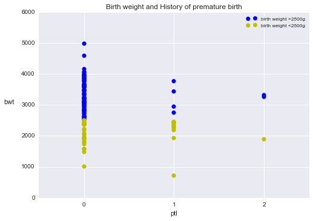

```python
# dataframe for bwt & ptl (history of premature birth: 0 or 1 or more)
x_ptlbwt = x.loc[:, ['ptl','bwt']]
# plot points from training set of bwt and ptl
fig3 = pyplot.figure()
ax = fig3.add_subplot(1,1,1)
ax.scatter(x_ptlbwt.ix[y==0, 0], x_ptlbwt.ix[y==0, 1], c= 'b', edgecolors = 'b', label = 'birth weight >2500g', s= 45) # ptl
ax.scatter(x_ptlbwt.ix[y==1, 0], x_ptlbwt.ix[y==1, 1], c= 'y', edgecolors = 'y', label = 'birth weight <2500g', s= 45) # bwt
#pyplot.xlim(x_ageptl[['age']].min() - 2  , x_ageptl[['age']].max() + 2 ) # set limits of x axis (age)
#pyplot.ylim(x_ageptl[['ptl']].min() - 2, x_ageptl[['ptl']].max() + 2 ) # set limits of y axis (race)
pyplot.xlabel(x_ptlbwt.columns[0])
pyplot.ylabel(x_smokebwt.columns[1], rotation=0, labelpad=20) #rotate label and add space
ax.legend(loc = 'best', fontsize='small', scatterpoints=2, fancybox = True)
ax.set_title('Birth weight and History of premature birth', fontsize = 'large')

# change tick labels for number of premature births
x_TickNew = [item for item in ['0','1','2']]
# get tick labels
xplot_labels = [item.get_text() for item in ax.get_xticklabels()]
# change to only 2 labels - No and Yes
xplot_labels[0]='0'
xplot_labels[1]='1'
xplot_labels[2]='2'
ax.set_xticklabels(x_TickNew)
# need to also change the ticks for x-axis
ax.set_xticks([0,1,2])


pyplot.show(fig3)
```

#### Frequency of age and birth weight

```
array([<matplotlib.axes._subplots.AxesSubplot object at 0x109c83f10>,
       <matplotlib.axes._subplots.AxesSubplot object at 0x1098d90d0>], dtype=object)
```

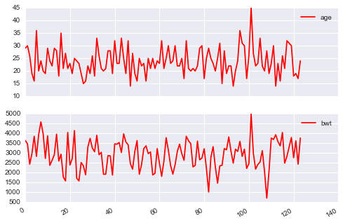

```python
x_racebwt_2.plot(kind='line', subplots=True, color='r')
```

```python
x_racebwt_2.loc[x_racebwt_2.race==var, ['age','bwt']].head()
```

|  | age | bwt |
| --- | --- | --- |
| 1 | 30 | 3475 |
| 2 | 26 | 2442 |
| 9 | 19 | 2733 |
| 14 | 28 | 3969 |
| 18 | 27 | 1588 |

#### Interested in seeing subset of women who smoke and give birth to low weight babies

```python
# subset smoking ==1 and low birth weight ==1
smoking_low = training[training.low.isin([1]) & training.smoke.isin([1])]
print("Women who smoke and are 'other' race - with low birth weight babies:\n", smoking_low[smoking_low.race ==3])
print()
print("Count of women who smoke and are white - with low birth weight:", np.count_nonzero(smoking_low.race[smoking_low.race ==1]))
print()
print("Women who smoke and are 'black - with low birth weight babies:\n", smoking_low[smoking_low.race ==2])
```

```
Women who smoke and are 'other' race - with low birth weight babies:
      age  lwt  race  smoke  ptl  ht  ui  ftv   bwt  low
47    14  101     3      1    1   0   0    0  2466    1
60    23   94     3      1    0   0   0    0  2495    1
108   28  120     3      1    1   0   1    0   709    1

Count of women who smoke and are white - with low birth weight: 15

Women who smoke and are 'black - with low birth weight babies:
     age  lwt  race  smoke  ptl  ht  ui  ftv   bwt  low
11   24  105     2      1    0   0   0    0  2381    1
65   23  187     2      1    0   0   0    1  2367    1
76   20  122     2      1    0   0   0    0  2381    1
```

#### Density Estimations of Birth Weight by Race

In looking at the different populations in the training sample, white women represent the majority while black women are the least.

Next, I wanted to explore the different distributions of birth weight by race, so I used the kernel density estimate to plot these. When I initially plotted these, all densities kind of looked similar, but when putting all variables on the same x and y axis, I noticed that white women had similar distributions to other women with more variance in the birth weights while black women had the narrowest distribution of all.

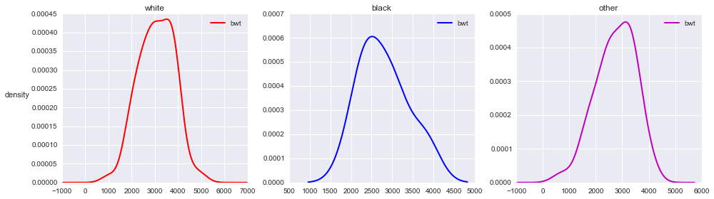

```python
# density plot of birth weight by race
fig1, axes = pyplot.subplots(nrows=1, ncols=3, figsize=(14,4))
for i, var in enumerate(['white','black','other']):
    x_racebwt_v2.loc[x_racebwt_v2.race == var].plot(kind = 'kde', ax = axes[i], color = cols[i], title = var, lw =2)
    axes[i].set_ylabel('')
axes[0].set_ylabel('density', rotation = 0, labelpad = 20)
fig1.subplots_adjust(hspace=0.25, wspace=0.25)
pyplot.tight_layout()
pyplot.show()
```

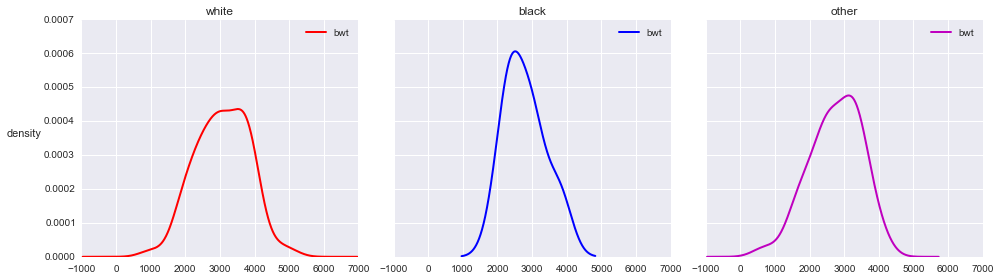

```python
# density plot of birth weight by race - share x and y axes
fig2, axes = pyplot.subplots(nrows=1, ncols=3, figsize=(14,4), sharex=True, sharey=True)
for i, var in enumerate(['white','black','other']):
    x_racebwt_v2.loc[x_racebwt_v2.race == var].plot(kind = 'kde', ax = axes[i], color = cols[i], title = var, lw =2)
    axes[i].set_ylabel('')
axes[0].set_ylabel('density', rotation = 0, labelpad = 20)
fig2.subplots_adjust(hspace=0.25, wspace=0.25)
pyplot.tight_layout()
pyplot.show()
```

### Seaborn Package KDE plot function

I also explored the seaborn package and used the KDE plot function to look at the density estimate of race and birth weight ($1^{st}$) as well as age and birth weight ($2^{nd}$).

The $1^{st}$ kde plot shows that the lowest points come from the white and other race women samples, and that the birth weight varies less for black women.

The $2^{nd}$ plot shows that birth weight $<1000g$ comes from women around 27-30 years old, and that there arent any low births for women at the maximum age in the training set. The maximum age for women is 45 and there are no low birth weight babies.

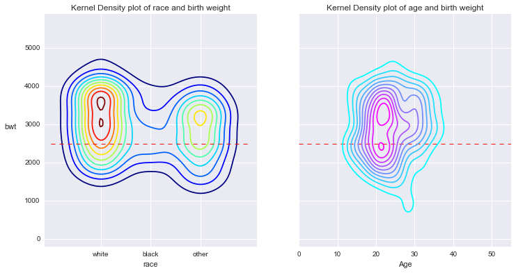

```python
# This plot uses the seaborn package to plot a density estimate of birthweight and race and birthweight and age
# add a horizontal line at 2500 to separate low birth weight in both plots


# seaborn kde plot of race and birth weight
fig, (ax1,ax2) = pyplot.subplots(nrows=1, ncols = 2, sharey = True, figsize = (12,6))
sns.kdeplot(x_racebwt.race, x_racebwt.bwt, ax=ax1, c= training.low, cmap = cm.jet)
# could also do this
# sns.kdeplot(x_racebwt[['race','bwt']], ax=ax, c= training.low, cmap = cm.jet)
ax1.set_xlabel("race")
ax1.set_ylabel("bwt", rotation =0, labelpad=20)
ax1.set_title("Kernel Density plot of race and birth weight")
# change tick labels for race
x_TicksNew = [item for item in ['white','black','other']]
# change labels
x_plot_labels = [item.get_text() for item in ax1.get_xticklabels()]
x_plot_labels[1] = 'White'
x_plot_labels[2]='Black'
x_plot_labels[3]='Other'
ax1.set_xticklabels(x_TicksNew)
ax1.set_xticks([1,2,3]);
ax1.hlines(y=2500,xmin=0, xmax=4, color='r', lw=1, linestyle='--');


# seaborn kde plot of age and birth weight
ax2.set_xlabel("Age")
ax2.set_title("Kernel Density plot of age and birth weight")
ax2.hlines(y=2500,xmin=0, xmax=55, color='r', lw=1, linestyle='--')
sns.kdeplot(x_racebwt_2[['age','bwt']], ax=ax2, c= training.low, cmap = cm.cool);
```

Also, when looking at the densities of all races, it becomes even more apparent that white women tend to have averages around $3000g$ whereas black and other women have average baby weights below $3000g$.

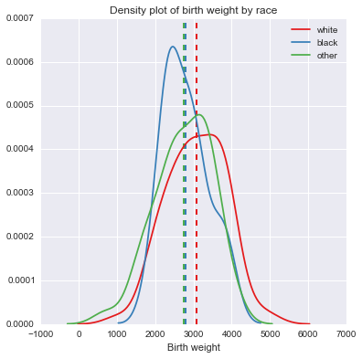

```python
# plot distribution of each race on top of one another
fig3, ax = pyplot.subplots(nrows=1, ncols=1, sharey=True, sharex=True, figsize=(6,6))
whites = x_racebwt.loc[x_racebwt.race==1]
blacks = x_racebwt.loc[x_racebwt.race==2]
others = x_racebwt.loc[x_racebwt.race==3]
# set different colors using seaborn palettes
c1, c2, c3 = sns.color_palette("Set1", 3)

sns.kdeplot(whites['bwt'], ax = ax, color =c1, label="white");
sns.kdeplot(blacks['bwt'], ax = ax, color =c2, label="black");
sns.kdeplot(others['bwt'], ax = ax, color =c3, label="other");
# add a vertical line for each mean weight by race
ax.vlines(x=whites.bwt.mean(),ymin=0, ymax=0.0007, color=c1, lw=2, linestyle='--') #add mean for white women
ax.vlines(x=blacks.bwt.mean(),ymin=0, ymax=0.0007, color=c2, lw=2, linestyle='--') #add mean for black women
ax.vlines(x=others.bwt.mean(),ymin=0, ymax=0.0007, color=c3, lw=2, linestyle='--') #add mean for other women
ax.set_title("Density plot of birth weight by race");
ax.set_xlabel("Birth weight");
```

#### Displot

I also briefly explored the distplot function from the seaborn package which allows you to combine histograms and kernel density plots easily. The below shows the dist plot (histogram and a kernel density plot on top) of race and birthweight.

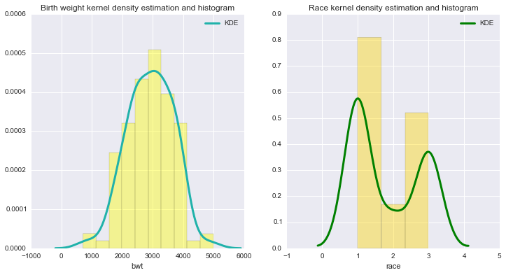

```python
from scipy import stats
fig4, (ax1, ax2) = pyplot.subplots(nrows=1, ncols=2, figsize=(12,6))
# bwt distplot
sns.distplot(x_racebwt['bwt'], kde=True, hist = True , color ='yellow',
             kde_kws={"color": "lightseagreen", "lw": 3, "label": "KDE"},
             ax = ax1);
ax1.set_title("Birth weight kernel density estimation and histogram");

# Race distplot
sns.distplot(x_racebwt['race'], kde=True, hist = True , color ='gold',
             kde_kws={"color": "green", "lw": 3, "label": "KDE"},
             ax = ax2);
ax2.set_title("Race kernel density estimation and histogram");
```

#### Jointplot

Next, I looked at the jointplot function in the seaborn package to visualize the joint distribution of lwt and birth weight as well as the marginal distribution of each variable with a line for the mean of each variable in red.

```
   lwt  race   bwt
0  135     1  3651
1  110     3  3475
2  154     3  2442
3  138     1  2977
4  170     2  3860
```

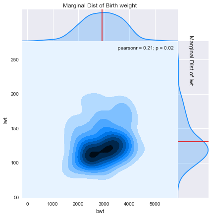

```python
x_lwtrace = x.loc[:, ['lwt','race','bwt']]
print(x_lwtrace.head())
sns.set_palette("Paired");
ax = sns.jointplot(x = x_lwtrace.bwt, y = x_lwtrace.lwt, kind="kde", color="dodgerblue", space =0);
ax.set_axis_labels(ylabel = "lwt", xlabel="bwt");
ax.ax_marg_x.set_title("Marginal Dist of Birth weight");
ax.ax_marg_x.axvline(x=x_lwtrace.bwt.mean(), ymin=0, ymax=1, color = c1);
ax.ax_marg_y.set_title("Marginal Dist of lwt", rotation = 270, fontdict={'horizontalalignment':"right"} );
ax.ax_marg_y.axhline(y=x_lwtrace.lwt.mean(), xmin=0, xmax=1, color = c1);
```

### Logistic regression using $L_1$ penalty - yields spare coefficients.

Here we explore the different results and predictions in the training and test set.

The coefficient plot shows that when the regularization penalty $C$ is set to $1.0$ (default), the largest coefficients correspond to smoke (yes/no), race (black, white or other.) and ptl (history of premature labor).

However, when we decrease $C$ to $0.01$, the largest coefficient remaining corresponds to lwt and the others are nearly 0.

```python
#L1 model for Logistic Regression - use L1 Penalty for sparse coefficients
l1 = linear_model.LogisticRegression(penalty ='l1', C=1.0, fit_intercept = True)
# fit l1 model to data
l1.fit(x,y)
#  these are the predictions based on x and L1 model (training set)
y_pred_train = l1.predict(x)
# model accuracy
model_accuracy = accuracy_score(label_train, y_pred_train)
# incorrect number of classifications
incorrect_class = (1-model_accuracy)*train.shape[0]
```

```python
print('--------Results on Training set:--------\n')
print('Coefficients with L1 penalty:\n',l1.coef_)
print()
print('Model', l1.penalty, ' score is: ',l1.score(x,y))
print('Accuracy score is: ', model_accuracy, 'Need to make sure this approach is correct***')
print('Number of incorrect predictions: ', incorrect_class)
```

```
--------Results on Training set:--------

Coefficients with L1 penalty:
 [[-0.00948316  0.01845867  0.5688261   1.00486737  0.53569598  0.          0.
   0.         -0.00574859]]

Model l1  score is:  0.959677419355
Accuracy score is:  0.959677419355 Need to make sure this approach is correct***
Number of incorrect predictions:  5.0
```

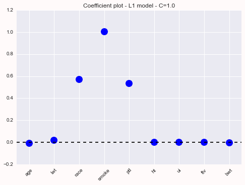

```python
# get coefficients from L1 model
coefs = l1.coef_[0]
# plot coefficients of L1 model and
fig = pyplot.figure(facecolor='snow')
pyplot.plot(coefs, 'ro', markerfacecolor='blue', markersize=14, markeredgecolor = 'r')
pyplot.xlim(-0.5, 8.5)
pyplot.xticks(range(len(coefs)), x.columns.values, rotation=45)
pyplot.axhline(0, color='k', linestyle='--')
pyplot.title('Coefficient plot - L1 model - C='+ str(l1.C))
```

```python
# print L1 coefficients
print('C =',l1.C, ' - L1 coefficients:\n')
for name, value in zip(x.columns, l1.coef_[0]):
    print('{0}:\t{1:.7f}'.format(name, value))
```

```
C = 1.0  - L1 coefficients:

age:	-0.0094832
lwt:	0.0184587
race:	0.5688261
smoke:	1.0048674
ptl:	0.5356960
ht:	0.0000000
ui:	0.0000000
ftv:	0.0000000
bwt:	-0.0057486
```

```python
# test set used here
y_test = np.ravel(label_test)
# these are the predictions based on x and L1 model (training set)
y_pred_test = l1.predict(test)
# model accuracy
test_accuracy = accuracy_score(label_test, y_pred_test) # Is this correct???
# l1 score
l1_score = l1.score(test,y_test)
# incorrect number of classifications
test_incorrect_class = (1-l1_score)*test.shape[0]
```

```python
print('-------- L1 Results on Test set:--------\n')
print('Model', l1.penalty, ' score is: ',l1.score(test,y_test))
print('Accuracy score is: ', test_accuracy)
print('Number of incorrect predictions: ', test_incorrect_class)
```

```
-------- L1 Results on Test set:--------

Model l1  score is:  0.984615384615
Accuracy score is:  0.984615384615
Number of incorrect predictions:  1.0
```

```python
result = l1.predict(test)
print('Predictions on test:')
print(result)
predict_prob = l1.predict_proba(test)
```

```
Predictions on test:
[0 1 0 0 0 0 0 0 0 1 0 0 0 1 0 0 0 1 0 0 0 1 1 0 0 1 0 1 0 0 1 0 1 0 1 0 0
 1 0 0 0 0 0 0 0 0 1 0 0 0 0 0 0 0 0 0 0 1 1 1 0 0 0 1 0]
```

Changing the regularization term $C = 0.01$: this yields coefficients very close to 0.

```
C = 0.01  - L1 coefficients:
age:	0.0000000
lwt:	0.0310291
race:	0.0000000
smoke:	0.0000000
ptl:	0.0000000
ht:	0.0000000
ui:	0.0000000
ftv:	0.0000000
bwt:	-0.0018253
```

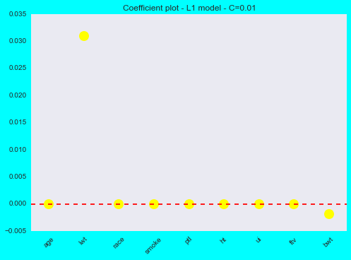

```python
#L1_v2: model for Logistic Regression - use L1 Penalty for sparse coefficients - C = .01
l1_v2 = linear_model.LogisticRegression(penalty ='l1', C=.010, fit_intercept = True)
# fit l1_v2 model to data
l1_v2.fit(x,y)
# print L1_v2 coefficients
print('C =',l1_v2.C, ' - L1 coefficients:')
for name, value in zip(x.columns, l1_v2.coef_[0]):
    print('{0}:\t{1:.7f}'.format(name, value))
# get coefficients from L1_v2 model
coefs_v2 = l1_v2.coef_[0]
# plot coefficients of L1 model and
fig1 = pyplot.figure(facecolor='cyan')
pyplot.plot(coefs_v2, 'ro', markerfacecolor='yellow', markersize=14, markeredgecolor = 'r')
pyplot.xlim(-0.5, 8.5)
pyplot.xticks(range(len(coefs_v2)), x.columns.values, rotation=45)
pyplot.axhline(0, color='r', linestyle='--')
pyplot.grid()
pyplot.title('Coefficient plot - L1 model - C='+ str(l1_v2.C))
```

### Logistic Regression using $L_2$ penalty

When looking at the $L_2$ penalty with $C=1.0$, the model performs a bit worse on the test set, and the coefficients are not as close to 0.

When setting $C = 1000$ the coefficient corresponding to history of premature labor (ptl) is highest.

```python
#L2 model for Logistic Regression - use L2 Penalty
l2 = linear_model.LogisticRegression(penalty ='l2', C=1.0, fit_intercept = True)
# fit l2 model to data
l2.fit(x,y)
# these are the predictions based on x and L1 model (training set)
y_pred_train_l2 = l2.predict(x)
# this is L2 model score
l2_score = l2.score(test, y_test)
# incorrect number of classifications on test set
test_incorrect_class_l2 = (1-l2_score)*test.shape[0]
```

```python
print('-------- L2 Results on Test set:--------\n')
print('Model', l2.penalty, ' score is: ',l2.score(test,y_test))
print('Number of incorrect predictions: ', test_incorrect_class_l2)
```

```
-------- L2 Results on Test set:--------

Model l2  score is:  0.907692307692
Number of incorrect predictions:  6.0
```

```
C = 1.0  - L2 coefficients:
age:	0.0478285
lwt:	0.0289740
race:	1.0237721
smoke:	1.4929413
ptl:	0.4912715
ht:	0.3326577
ui:	0.1681403
ftv:	-0.0059294
bwt:	-0.0039292
```

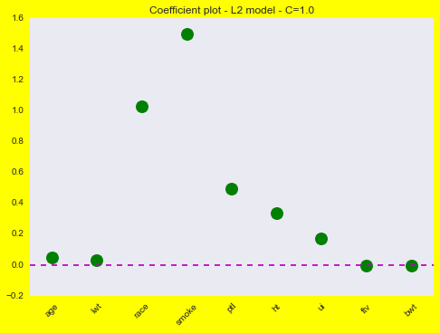

```python
# print L2 coefficients
print('C =',l2.C, ' - L2 coefficients:')
for name, value in zip(x.columns, l2.coef_[0]):
    print('{0}:\t{1:.7f}'.format(name, value))
# get coefficients from L2 model
coefs_l2 = l2.coef_[0]
# plot coefficients of L2 model and
fig2 = pyplot.figure(facecolor='yellow')
pyplot.plot(coefs_l2, 'ro', markerfacecolor='green', markersize=14, markeredgecolor = 'r')
pyplot.xlim(-0.5, 8.5)
pyplot.xticks(range(len(coefs_l2)), x.columns.values, rotation=45)
pyplot.axhline(0, color='m', linestyle='--')
pyplot.grid()
pyplot.title('Coefficient plot - L2 model - C='+ str(l2.C))
```

Changing $C = 1000$ for $L_2$ penalty:

```
C = 1000  - L2 coefficients:
age:	-0.0620169
lwt:	0.0294959
race:	1.1888958
smoke:	1.8584039
ptl:	2.0503467
ht:	1.7983696
ui:	-0.9007075
ftv:	-0.0505346
bwt:	-0.0071715
```

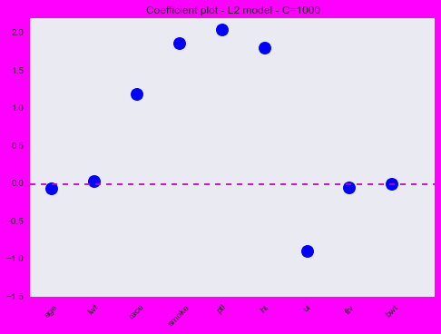

```python
#L2_v2: model for Logistic Regression - use L2 Penalty - C = 1000
l2_v2 = linear_model.LogisticRegression(penalty ='l2', C=1000)
# fit l1_v2 model to data
l2_v2.fit(x,y)
# print L1_v2 coefficients
print('C =',l2_v2.C, ' - L2 coefficients:')
for name, value in zip(x.columns, l2_v2.coef_[0]):
    print('{0}:\t{1:.7f}'.format(name, value))
# get coefficients from L2_v2 model
coefs_l2_v2 = l2_v2.coef_[0]
# plot coefficients of L2 model and
fig3 = pyplot.figure(facecolor='magenta')
pyplot.plot(coefs_l2_v2, 'ro', markerfacecolor='blue', markersize=14)
pyplot.xlim(-0.5, 8.5)
pyplot.ylim(-1.5, 2.2)
pyplot.xticks(range(len(coefs_l2_v2)+1), x.columns.values, rotation=45)
pyplot.axhline(0, color='m', linestyle='--')
pyplot.grid()
pyplot.title('Coefficient plot - L2 model - C='+ str(l2_v2.C))
```

## Predictions

```python
# create subset with data only for age and race to train
x_race_data = training.loc[:,['smoke','race','low']]
x_race_train = x_race_data.loc[:,['smoke','race']]
x_race_label = x_race_data.loc[:,['low']]
x_race_train_labels = x_race_label.loc[:,'low'] #make same shape as the predictions
# make test set for this subset
x_race_test_data = x_test.loc[:,['smoke','race']]
x_race_test_label = np.ravel(label_test)
```

```python
#L2 model for Logistic Regression - for subset with only 2 features: race and smoke
logRegmodel = linear_model.LogisticRegression()
# fit l1 model to data
logRegmodel.fit(x_race_train, x_race_train_labels)
#  these are the predictions based on x and L2 model (training set)
x_race_predictions = logRegmodel.predict(x_race_train)
# this is L2 model score
logRegmodel_score = logRegmodel.score(x_race_test_data, x_race_test_label)
# incorrect number of classifications
test_wrong_class = (1-logRegmodel_score) * x_race_test_data.shape[0]
```

```python
print('-------- Results on Test set:--------\n')
print('Model', logRegmodel.penalty, ' score is: ', logRegmodel_score)
print('Number of incorrect predictions: ', test_wrong_class)
```

```
-------- Results on Test set:--------

Model l2  score is:  0.707692307692
Number of incorrect predictions:  19.0
```

### PCA

Next, I wanted to learn about Principal Component Analysis (PCA) to project the data into less dimensions. Performing PCA on a dataset returns principal components of the data (these are eigenvectors) such that the $1^{st}$ component has the largest possible variance which accounts for most of the variability in the dataset. Each principal component is associated with a value (eigen value) which corresponds to the amount of variance explained by that component.  
At first I used the *fit transform* function to see what the explained variance ratios would be if I did not reduce the dimensions but kept all 9. Since the explained variance ratio functions returns the ratios of each explained variance, the sum should add up to 1. Also, in looking at the *explained variances*, the highest value is the first one corresponding to the largest amount of variability in the dataset.

```python
# http://nbviewer.ipython.org/github/anfibil/cse40647.sp14/blob/master/8%20-%20Dimensionality%20Reduction.ipynb
from sklearn.decomposition import PCA
from sklearn import decomposition
pca = decomposition.PCA()
# use pca.fit_transform(x) on training set (need to use pca.transform(x) on test)
x_PCA = pca.fit_transform(x)
# get percentage of variance for each of the components to see which features have highest variance
print("Variance in data explained by each principal component:\n", pca.explained_variance_)
print()
print("Percentage of variance for each component before chosing k features to reduce to:\n",pca.explained_variance_ratio_)
print()
print("Since k is not set, the sum of variance of all components should be 0:", sum(pca.explained_variance_ratio_))
```

```
Variance in data explained by each principal component:
 [  5.55318219e+05   8.43498408e+02   2.89969495e+01   1.00653828e+00
   7.96284427e-01   2.29567363e-01   1.36490978e-01   9.18962870e-02
   5.03949663e-02]

Percentage of variance for each component before chosing k features to reduce to:
 [  9.98427153e-01   1.51655697e-03   5.21346873e-05   1.80969238e-06
   1.43166921e-06   4.12747647e-07   2.45402175e-07   1.65223731e-07
   9.06069728e-08]

Since k is not set, the sum of variance of all components should be 0: 1.0
```

## Choosing dimensions

Before chosing how many dimensions to reduce to, I plot the explained variance of each component to see where the largest variability in the data would be based on the largest variance. It looks like the most variance could be explained by just 1 principal component.

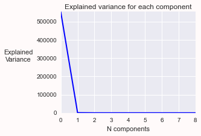

```python
# before selecting k components see where the largest variance is
pca = PCA()
pca.fit_transform(x)
fig_pca = pyplot.figure(num =1, figsize = (4,3), facecolor="snow")
ax = fig_pca.add_subplot(1,1,1)
ax.plot(pca.explained_variance_, linewidth = 2, color = "blue")
ax.axis('tight')
ax.set_ylabel(ylabel = "Explained\nVariance", rotation = 0, labelpad=30)
ax.set_xlabel('N components')
pyplot.title('Explained variance for each component');
```

```python
# pca with 5 components
N=5
pca = decomposition.PCA(n_components=N)
x_PCA = pca.fit_transform(x)
print(pd.DataFrame(pca.components_.T, columns=['PC-1', 'PC-2', 'PC-3', 'PC-4', 'PC-5'], index=x.columns))
print()
print(pca.explained_variance_ratio_)
```

```
           PC-1      PC-2      PC-3      PC-4      PC-5
age   -0.001058 -0.017813  0.999181 -0.034526 -0.000529
lwt   -0.008302 -0.999787 -0.017852 -0.001401 -0.004407
race   0.000253  0.005111 -0.015341 -0.407265 -0.871247
smoke  0.000139 -0.000054 -0.002066  0.060094  0.269429
ptl    0.000114  0.001934  0.008569 -0.009781  0.040221
ht     0.000010 -0.003040 -0.005160  0.004724  0.002950
ui     0.000184  0.000943  0.001522  0.015106  0.024889
ftv   -0.000054  0.000098  0.031229  0.910486 -0.407519
bwt   -0.999965  0.008321 -0.000913 -0.000094 -0.000115

[  9.98427153e-01   1.51655697e-03   5.21346873e-05   1.80969238e-06
   1.43166921e-06]
```

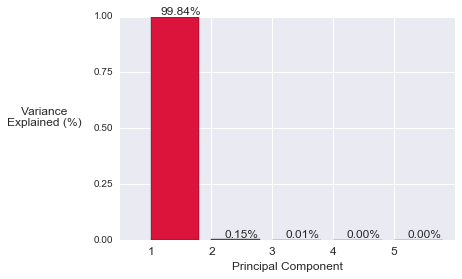

```python
# plot the percentage of each variance for each component
N = 5
ind = np.arange(N)
vals = pca.explained_variance_ratio_
y_breaks = np.arange(0.00,1.25, step=0.25)
x_plot_labels = ['1','2','3','4','5']
# plot of the 5 pca component percentages
fig_pca5 = pyplot.figure(figsize=(6,4))
ax = fig_pca5.add_subplot(1,1,1)
ax.bar(ind, pca.explained_variance_ratio_,
       color = ['crimson','DeepPink','Coral','Gold','PeachPuff'])
       #color = ['Crimson','DeepPink','Coral','Gold','PeachPuff','Lavender','Aqua','DeepSkyBlue','DarkBlue','Maroon'])
ax.annotate(r"%.2f%%" % (vals[0]*100), (ind[0]+0.5, vals[0]), va="bottom", ha="center", fontsize=12)
ax.annotate(r"%.2f%%" % (vals[1]*100), (ind[1]+ 0.5, vals[1]), va="bottom", ha="center", fontsize=12)
ax.annotate(r"%.2f%%" % (vals[2]*100), (ind[2]+ 0.5, vals[2]), va="bottom", ha="center", fontsize=12)
ax.annotate(r"%.2f%%" % (vals[3]*100), (ind[3]+ 0.5, vals[3]), va="bottom", ha="center", fontsize=12)
ax.annotate(r"%.2f%%" % (vals[4]*100), (ind[4]+ 0.5, vals[4]), va="bottom", ha="center", fontsize=12)
ax.set_xticklabels(labels = x_plot_labels, fontsize = 12)
ax.set_ylim(0, 1.0)
ax.set_xlim(-.5, 5.0)
ax.set_xticks([0,1,2,3,4,5])
ax.set_yticks(y_breaks)
ax.xaxis.set_tick_params(width=0)
ax.yaxis.set_tick_params(width=1, length=0)
ax.set_xlabel("Principal Component", fontsize=12)
ax.set_ylabel("Variance \nExplained (%)", fontsize=12, rotation = 0, labelpad=50);
```

```python
# print pca components based on k=2
N=2
pca = decomposition.PCA(n_components=N)
x_PCA = pca.fit_transform(x)
print(pd.DataFrame(pca.components_.T, columns=['PC-1', 'PC-2'], index=x.columns))
```

```
           PC-1      PC-2
age   -0.001058 -0.017813
lwt   -0.008302 -0.999787
race   0.000253  0.005111
smoke  0.000139 -0.000054
ptl    0.000114  0.001934
ht     0.000010 -0.003040
ui     0.000184  0.000943
ftv   -0.000054  0.000098
bwt   -0.999965  0.008321
```

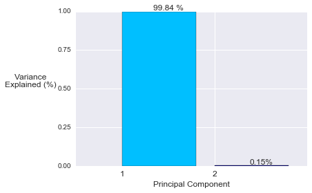

```python
# really helpful blog:
# http://nbviewer.ipython.org/github/anfibil/cse40647.sp14/blob/master/8%20-%20Dimensionality%20Reduction.ipynb
N = 2
ind = np.arange(N)
vals = pca.explained_variance_ratio_
y_breaks = np.arange(0.00,1.25, step=0.25)
x_plot_labels = ['1','2',]
# plot of the two pca component percentages
fig1 = pyplot.figure(figsize=(6,4))
ax = fig1.add_subplot(1,1,1)
ax.bar(ind, pca.explained_variance_ratio_,
       color = ['DeepSkyBlue','DarkBlue'])
       #color = ['Crimson','DeepPink','Coral','Gold','PeachPuff','Lavender','Aqua','DeepSkyBlue','DarkBlue','Maroon'])
ax.annotate(r"%.2f %%" % (vals[0]*100), (ind[0]+0.5, vals[0]), va="bottom", ha="center", fontsize=12)
ax.annotate(r"%.2f%%" % (vals[1]*100), (ind[1]+ 0.5, vals[1]), va="bottom", ha="center", fontsize=12)
ax.set_xticklabels(labels = x_plot_labels, fontsize = 12)
ax.set_ylim(0, 1.0)
ax.set_xlim(-.5, 2.0)
ax.set_xticks([0,1,2])
ax.set_yticks(y_breaks)
ax.xaxis.set_tick_params(width=0)
ax.yaxis.set_tick_params(width=1, length=0)
ax.set_xlabel("Principal Component", fontsize=12)
ax.set_ylabel("Variance \nExplained (%)", fontsize=12, rotation = 0, labelpad=40);
```

```python
# keep only 2 components with largest variances
pca.n_components = 2
x_reduced = pca.fit_transform(x)
print("x shape before PCA:", np.shape(x), "\nx shape after PCA:", np.shape(x_reduced))
print("PCA variance ratios:", pca.explained_variance_ratio_)
print()
print("Printing components in linear combination format:")
for component in pca.components_:
    print()
    print(" + ".join("%.5f*%s" % (value, name)
                     for value, name in zip(component, x.columns)))
```

```
x shape before PCA: (124, 9)
x shape after PCA: (124, 2)
PCA variance ratios: [ 0.99842715  0.00151656]

Printing components in linear combination format:

-0.00106*age + -0.00830*lwt + 0.00025*race + 0.00014*smoke + 0.00011*ptl + 0.00001*ht + 0.00018*ui + -0.00005*ftv + -0.99996*bwt

-0.01781*age + -0.99979*lwt + 0.00511*race + -0.00005*smoke + 0.00193*ptl + -0.00304*ht + 0.00094*ui + 0.00010*ftv + 0.00832*bwt
```

```python
print('explained variance ratio: %s'
      % str(pca.explained_variance_ratio_))
print('explained variance values: %s'
      % str(pca.explained_variance_))
```

```
explained variance ratio: [ 0.99842715  0.00151656]
explained variance values: [ 555318.21922504     843.49840762]
```

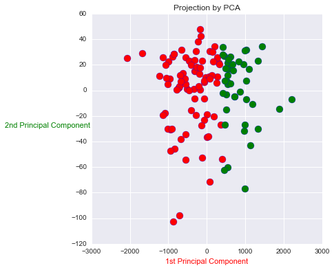

```python
# 1st scatter = plots datapoints in PCA 1
# 2nd scatter = plots datapoints in PCA 2
# x[y==0,0] will return the x's in 0th column where y==0 (pca 1)
# x[y==0,1] will return the x's in 1th column where y==0 (pca 2)
fig1 = pyplot.figure(figsize=(6,6))
ax = fig1.add_subplot(1,1,1)
ax.scatter(x_reduced[y==0,0], x_reduced[y==0,1], c='red', edgecolor ='b',  s=100)
ax.scatter(x_reduced[y==1,0], x_reduced[y==1,1], c='green', edgecolor ='b', s=100)
ax.grid(True)
ax.set_xlabel('1st Principal Component', color='red')
ax.set_ylabel('2nd Principal Component', color='green', rotation =0, labelpad=35)
ax.set_title(label = "Projection by PCA")
pyplot.show(fig1)
```

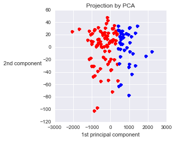

```python
# Another way of doing the same thing as above
reds = y==0
blues = y==1
fig2 = pyplot.figure(figsize=(4,4))
ax = fig2.add_subplot(1,1,1)
ax.plot(x_reduced[reds, 0], x_reduced[reds, 1], "ro")
ax.plot(x_reduced[blues, 0], x_reduced[blues, 1], "bo")
pyplot.title("Projection by PCA")
pyplot.xlabel("1st principal component")
pyplot.ylabel("2nd component", rotation =0, labelpad=35)
pyplot.show(fig2)
```

```python
# use whiten this time
pca_2= PCA(n_components=2, whiten=True)
pca_2.fit(x)
x_2 = pca_2.transform(x)
x_reconstructed = pca_2.inverse_transform(x_2) # x_reconstructed is now reconstructed x with fewer features
print("Pca explained variance ratio:",pca_2.explained_variance_ratio_)
print("Data is now centered:", np.round(x_2.mean(axis = 0), decimals=5)) # data is now centered
print("Data is now standardized:", np.round(x_2.std(axis = 0), decimals=5)) # data now has 1 standard dev
print("No longer correlated:",np.corrcoef(x_2.T)) # component samples no longer are correlated
```

```
Pca explained variance ratio: [ 0.99842715  0.00151656]
Data is now centered: [-0.  0.]
Data is now standardized: [ 1.  1.]
No longer correlated: [[  1.00000000e+00  -4.61458828e-15]
 [ -4.61458828e-15   1.00000000e+00]]
```

```
Pca explained variance ratio: [ 0.99842715]
```

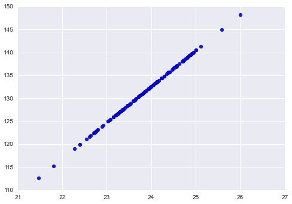

```python
# Since the first component is so large - keep only one dimension
pca_1= PCA(n_components=1)
pca_1.fit(x)
x_1 = pca_1.transform(x)
x_1_reconstructed = pca_1.inverse_transform(x_1) # x_reconstructed is now reconstructed x with fewer features
print("Pca explained variance ratio:",pca_1.explained_variance_ratio_)
pyplot.scatter(x_1_reconstructed[:,0], x_1_reconstructed[:,1],c='b', s=35, alpha=0.9)
X_n=(x - x.mean(axis=0))/x.std(axis=0) #normalize x
```

```python
# since x_1_reconstructed is reconstructed x with fewer features
# put into a data frame
x_1_reconstructed_v2 = pd.DataFrame(x_1_reconstructed, columns = ['age','lwt','race','smoke','ptl','ht','ui','ftv','bwt'] )
print(x_1_reconstructed_v2.head())
```

```
         age         lwt      race     smoke       ptl        ht        ui  \
0  24.588512  137.069044  1.623209  0.278489  0.086492  0.057356  0.011774
1  24.402161  135.606185  1.667792  0.302951  0.106653  0.059098  0.044227
2  23.310078  127.033287  1.929063  0.446308  0.224800  0.069307  0.234414
3  23.875728  131.473660  1.793737  0.372056  0.163605  0.064019  0.135906
4  24.809835  138.806445  1.570260  0.249436  0.062548  0.055287 -0.026769

        ftv          bwt
0  0.813197  3650.987707
1  0.803707  3474.793007
2  0.748095  2442.226486
3  0.776900  2977.049252
4  0.824467  3860.249767
```

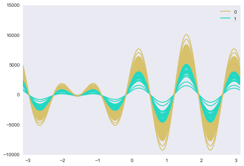

```python
from pandas.tools.plotting import andrews_curves
pyplot.figure()
andrews_curves(training, 'low')
```

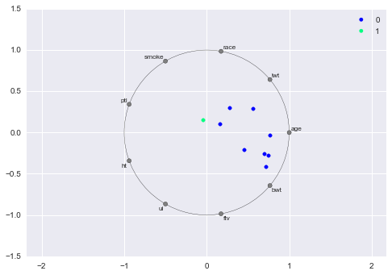

```python
#http://pandas.pydata.org/pandas-docs/version/0.13.1/visualization.html
from pandas.tools.plotting import radviz
pyplot.figure()
radviz(training, 'low', colormap='winter')
```